# LEAGUE OF LEGENDS by Santosh Yelavarthy

## Predicting who will win the game

# Outline

1. Introduction
2. Scraping Data
3. Organizing the Data
4. Further Organization
5. Popular Champions
6. Match Ups
7. Early game or Late game Champions
8. Objectives and their importance
9. Linear regression

## Introduction

League of Legends (LoL) is a multi-player, fast-paced, and competitive online game that blends the speed and intensity of an RTS (Real-Time Strategy) with RPG (Role Playing Game) elements. Two teams of powerful champions, each with a unique design and playstyle, battle head-to-head across multiple battlefields and game modes. The last player statistics released by the company in 2016 showed League has 100 million active players each month. Outside companies estimate this number has continued to rise over the last 2 years. In League of Legends, players assume the role of a "summoner" who controls a "champion" with unique abilities. They battle against a team of other players or computer-controlled champions. The goal is usually to destroy the opposing team's "nexus", a structure that lies at the heart of a base protected by defensive structures, although other distinct game modes exist as well. Each League of Legends match has all champions starting off fairly weak but increasing in strength by accumulating items and experience. There are more objectives that will be talked about later on in the project.

The game has risen in popularity to the point where the amount of viewers of 2017 finals for League of Legends had more then the NBA finals. This was a major step into esport and showed that there is a large consumer base for the game. This has lead to people doing many statistical analysis to give each team an advantage.

In this notebook, I will first understand the champions and how they work. Then I will try to predict who would win a game of League of Legends based on the team factors.

```python
#declares all the imports
import requests
import json
import time
import pandas as pd
import numpy as np
import matplotlib.pyplot as plt
import seaborn as sns
import warnings
import csv
from sklearn import linear_model
from sklearn.model_selection import train_test_split
from sklearn.linear_model import LogisticRegression
from sklearn.preprocessing import MinMaxScaler
from statsmodels import api as sm
warnings.filterwarnings('ignore')
```

# Scraping Data

I first had to get a dataset to work with. So I went to developer.riotgames.com that had [Riot's API documentation](https://developer.riotgames.com/api-methods/) . I then applied to get a production key so that I may take more then 30000 requests/10 mins. This way I was able to obtain all this match data. I chose to only get data from the top 2% of the players since they would have the most knowledge about the game and how it should be played. There is a rank called Challenger which contain the top 200 players in the NA server. I looked at their match history and found people they have played with recently and got their match history too. This way I was able to get a lot of matches to improve teh quality of my dataset. Right now, I am only using a 1/3 of my data set due to the large amount of games. This portion of the data set is around 40,000 games.

Look at [Scraping Data notebook](https://github.com/sunny24680/sunny24680.github.io/blob/master/Scraping%20Data.ipynb) to see how I scrape the data from the RIOT API.

I stored all the data I recievd into json and 1 csv file. I just imported them to this notebook so that the code looks cleaner and is more easiy to follow.

```python
#initializes the variable that is going to be used
sumtemp = {}
#the csv file stores the dictionary as a string to a string so I have to convert it back to an actual dictionary
with open('summoners.csv') as csv_file:
    reader = csv.reader(csv_file)
    sumtemp = dict(reader)

summoner = {}
#dealing with conversion form csv to a dict
for player in sumtemp:
    temp = {}
    d = sumtemp[player].split('\'')
    temp['accountId'] = d[3]
    temp['puuid'] = d[7]
    temp['lvl'] = d[10][2:]
    summoner[player] = temp

temp = {}
#the names are stored in a bit of a weird way, converting them to a dictionary so that I can easily change from ID to name
with open('champions.json') as json_data:
    temp = json.load(json_data)


champIdToName = {}
for index in temp:
    champIdToName[index['id']] = index

matchData = []
with open('newMatchData.json') as json_data:
    matchData = json.load(json_data)

champs = {}
for data in champIdToName:
    ID = champIdToName[data]['id']
    temp = {}
    temp['name'] = champIdToName[data]['name']
    champs[ID] = temp
```

Below is an example of the match data I was able to retrieve. This data does not tell every play that ever occured but tells you what happened in a 10 min interval period.

```python
matchData[0]
```

```
{'gameId': 2919948144,
 'platformId': 'NA1',
 'gameCreation': 1543377885176,
 'gameDuration': 859,
 'queueId': 420,
 'mapId': 11,
 'seasonId': 11,
 'gameVersion': '8.23.254.717',
 'gameMode': 'CLASSIC',
 'gameType': 'MATCHED_GAME',
 'teams': [{'teamId': 100,
   'win': 'Win',
   'firstBlood': True,
   'firstTower': True,
   'firstInhibitor': True,
   'firstBaron': False,
   'firstDragon': False,
   'firstRiftHerald': True,
   'towerKills': 9,
   'inhibitorKills': 2,
   'baronKills': 0,
   'dragonKills': 0,
   'vilemawKills': 0,
   'riftHeraldKills': 1,
   'dominionVictoryScore': 0,
   'bans': [{'championId': 104, 'pickTurn': 1},
    {'championId': 121, 'pickTurn': 2},
    {'championId': 5, 'pickTurn': 3},
    {'championId': 142, 'pickTurn': 4},
    {'championId': 39, 'pickTurn': 5}]},
  {'teamId': 200,
   'win': 'Fail',
   'firstBlood': False,
   'firstTower': False,
   'firstInhibitor': False,
   'firstBaron': False,
   'firstDragon': False,
   'firstRiftHerald': False,
   'towerKills': 0,
   'inhibitorKills': 0,
```

[output cut: 1285 more lines]

```
    'summonerName': 'Koggle',
    'summonerId': '1If5OolMVXYwTsx-yUlRZeIzKJVD2HrkGRM0UdrdEj-pYDs',
    'currentPlatformId': 'NA1',
    'currentAccountId': 'FnkUY_tzXMvGyVvVE5fQzZ9eX3blyhCst-IpWTADg7I7KsU',
    'matchHistoryUri': '/v1/stats/player_history/NA1/215257459',
    'profileIcon': 773}},
  {'participantId': 10,
   'player': {'platformId': 'NA1',
    'accountId': '0nD-WYqO4halMos8wMdQLrERyQUVAZNKKxDImaia63xncgE',
    'summonerName': 'KillerUnit',
    'summonerId': 'u6Ff7x5uRnLCKyKYW10Fojj23Nc0JJidWlPp3Aynsjxcvtg',
    'currentPlatformId': 'NA1',
    'currentAccountId': '0nD-WYqO4halMos8wMdQLrERyQUVAZNKKxDImaia63xncgE',
    'matchHistoryUri': '/v1/stats/player_history/NA1/208870229',
    'profileIcon': 917}}]}
```

## Organizing the Data

Now that I have the match data I have to organize it into a dataframe that can be more easily translated. The problem with this is that each match has two teams of five players each. To account for this difference, I had two dataframes stored. This next cell is used to get data for each participant. The main index we used in this data frame is champID becuase this data was used to see how each champion does in the game. I also tidyied the data to check for missing values. Since the game can end before ten mins, that means that the game was remade. This result is due to someone not connecting to the game, however the game was still stored as a value. To tidy the data from these outliers, I had to drop NaN rows. This would occur since the xpPerMinDelta would have nothing since ten mins havent passed yet.

```python
m = 0
for match in matchData:
    m = m + 1
    team1Champs = []
    team2Champs = []
    #organize the 2 teams
    for participant in match['participants']:
        champId = participant['championId']
        teamId = participant['teamId']
        if teamId == 100:
            team1Champs.append(champId)
        else:
            team2Champs.append(champId)

    #organizing all champion data from each match
    for teamData in match['teams']:
        #get which champions were banned
        for banned in teamData['bans']:
            champId = banned['championId']
            if 'bans' not in champs[champId]:
                champs[champId]['bans'] = 0
            champs[champId]['bans'] = champs[champId]['bans'] + 1

    #get the stats from each participant in the game
    for participant in match['participants']:
        champId = participant['championId']
        teamId = participant['teamId']
        if 'stats' not in champs[champId]:
            champs[champId]['stats'] = []
        temp = participant['stats']
        if teamId == 100:
            temp['opponents'] = team2Champs
        else:
            temp['opponents'] = team1Champs
        champs[champId]['stats'].append(temp)
        if 'timeline' not in champs[champId]:
            champs[champId]['timeline'] = []
        champs[champId]['timeline'].append(participant['timeline'])
```

## Further organizing

The data I have now is all over the place. I have to condensce it into one dataframe so that I can do the proper statistics on it. I merege the two different dictionaries of the same game and participant. This results in a dataframe that will contain all the data that a specific champion has played in and their statistics in that match

```python
champData = {}
#converting the dictionary I have on each champion to a DataFrame
for champId in champs:
    if 'stats' in champs[champId]:
        stats = pd.DataFrame.from_dict(champs[champId]['stats'])
        timeline = pd.DataFrame.from_dict(champs[champId]['timeline'])
        champData[champId] = pd.concat([stats, timeline], axis=1)
```

```python
champData[5].head()
```

|  | assists | champLevel | combatPlayerScore | damageDealtToObjectives | damageDealtToTurrets | damageSelfMitigated | deaths | doubleKills | firstBloodAssist | firstBloodKill | ... | creepsPerMinDeltas | csDiffPerMinDeltas | damageTakenDiffPerMinDeltas | damageTakenPerMinDeltas | goldPerMinDeltas | lane | participantId | role | xpDiffPerMinDeltas | xpPerMinDeltas |
| --- | --- | --- | --- | --- | --- | --- | --- | --- | --- | --- | --- | --- | --- | --- | --- | --- | --- | --- | --- | --- | --- |
| 0 | 10 | 15 | 0 | 20356 | 1158 | 22747 | 3 | 0 | False | False | ... | {'10-20': 0.8999999999999999, '0-10': 0.2, '20... | NaN | NaN | {'10-20': 1010.9000000000001, '0-10': 404.7, '... | {'10-20': 395.4, '0-10': 255.6, '20-30': 292.5} | JUNGLE | 5 | NONE | NaN | {'10-20': 565.2, '0-10': 273.6, '20-30': 522.2} |
| 1 | 3 | 12 | 0 | 3074 | 0 | 11160 | 4 | 0 | False | False | ... | {'10-20': 0.30000000000000004, '0-10': 1.1} | {'10-20': -3.5999999999999996, '0-10': 0.20000... | {'10-20': 255.10000000000002, '0-10': 24} | {'10-20': 935, '0-10': 681.3} | {'10-20': 432.1, '0-10': 293.5} | JUNGLE | 8 | NONE | {'10-20': -217.90000000000003, '0-10': -49.8} | {'10-20': 490.4, '0-10': 305.7} |
| 2 | 4 | 10 | 0 | 2343 | 0 | 9253 | 6 | 0 | False | False | ... | {'10-20': 1.9000000000000001, '0-10': 1.3} | {'10-20': -2, '0-10': 0.20000000000000007} | {'10-20': 254.19999999999993, '0-10': 136.5} | {'10-20': 1047.3, '0-10': 590.3} | {'10-20': 294.5, '0-10': 341.3} | JUNGLE | 1 | NONE | {'10-20': -420, '0-10': -104.5} | {'10-20': 344.5, '0-10': 355.5} |
| 3 | 10 | 15 | 0 | 21117 | 4017 | 16738 | 6 | 2 | False | False | ... | {'10-20': 0.8, '0-10': 0.30000000000000004} | {'10-20': -1, '0-10': 0} | {'10-20': -98.70000000000005, '0-10': 140.3999... | {'10-20': 1331.1, '0-10': 769.2} | {'10-20': 435.7, '0-10': 294.3} | JUNGLE | 7 | NONE | {'10-20': 67.59999999999997, '0-10': -165.5000... | {'10-20': 522.5999999999999, '0-10': 301.5} |
| 4 | 2 | 10 | 0 | 13173 | 1314 | 5329 | 0 | 0 | False | False | ... | {'0-10': 0.2} | {'0-10': 0.4399999999999995} | {'0-10': 75.13999999999999} | {'0-10': 718.7} | {'0-10': 264} | NONE | 3 | DUO_SUPPORT | {'0-10': 14.739999999999952} | {'0-10': 336.2} |

5 rows × 115 columns

## Popular(Meta) Champions

We will try to see who are the most popular champions in the game and which champions people do not like to play agaisnt. I found the winrate/pickrate/banrate for each champion. This will give us a general idea of which champions are prefered over others. There is generally a reason to why these champions are better in the given "meta".

```python
#get winrate of each champion
winrate = {}
for champId in champData:
    c = 0
    for index, row in champData[champId].iterrows():
        if row.loc['win'] == True:
            c = c + 1
    winrate[champId] = c/len(champData[champId])
```

```python
rate = pd.DataFrame(columns=['Champion', 'Win Rate', 'Ban Rate', 'Pick Rate'])
x = 0
for champId in champIdToName:
    if champId != -1:
        res = {}
        res['Champion'] = champIdToName[champId]['name']
        res['Win Rate'] = winrate[champId]
        res['Ban Rate'] = champs[champId]['bans']/len(matchData)
        res['Pick Rate'] = len(champData[champId])/len(matchData)
        rate.loc[x] = res
        x = x + 1
rate
```

|  | Champion | Win Rate | Ban Rate | Pick Rate |
| --- | --- | --- | --- | --- |
| 0 | Annie | 0.535658 | 0.020595 | 0.055441 |
| 1 | Olaf | 0.493807 | 0.006452 | 0.026308 |
| 2 | Galio | 0.482548 | 0.018922 | 0.039213 |
| 3 | Twisted Fate | 0.500743 | 0.007408 | 0.073146 |
| 4 | Xin Zhao | 0.504742 | 0.083335 | 0.103083 |
| 5 | Urgot | 0.514802 | 0.157785 | 0.082922 |
| 6 | LeBlanc | 0.498930 | 0.286416 | 0.101497 |
| 7 | Vladimir | 0.504895 | 0.105972 | 0.073233 |
| 8 | Fiddlesticks | 0.481199 | 0.032239 | 0.042754 |
| 9 | Kayle | 0.514218 | 0.002303 | 0.018335 |
| 10 | Master Yi | 0.502919 | 0.132128 | 0.070713 |
| 11 | Alistar | 0.497626 | 0.131477 | 0.118963 |
| 12 | Ryze | 0.427578 | 0.011688 | 0.053095 |
| 13 | Sion | 0.507384 | 0.059829 | 0.107384 |
| 14 | Sivir | 0.501495 | 0.005627 | 0.079924 |
| 15 | Soraka | 0.512744 | 0.040342 | 0.080120 |
| 16 | Teemo | 0.498838 | 0.039430 | 0.056093 |
| 17 | Tristana | 0.479171 | 0.031609 | 0.105863 |
| 18 | Warwick | 0.515961 | 0.089114 | 0.062610 |
| 19 | Nunu & Willump | 0.498990 | 0.024462 | 0.032261 |
| 20 | Miss Fortune | 0.522365 | 0.030393 | 0.096652 |
| 21 | Ashe | 0.503921 | 0.002259 | 0.052638 |
| 22 | Tryndamere | 0.521583 | 0.072256 | 0.060394 |
| 23 | Jax | 0.500064 | 0.293129 | 0.168430 |
| 24 | Morgana | 0.491931 | 0.223111 | 0.119811 |
| 25 | Zilean | 0.510022 | 0.015968 | 0.048771 |
| 26 | Singed | 0.532461 | 0.027134 | 0.044839 |
| 27 | Evelynn | 0.492521 | 0.218114 | 0.058091 |
| 28 | Twitch | 0.523239 | 0.034868 | 0.074319 |
| 29 | Karthus | 0.519661 | 0.048337 | 0.035911 |
| ... | ... | ... | ... | ... |
| 112 | Gnar | 0.499240 | 0.007669 | 0.028589 |
| 113 | Zac | 0.489780 | 0.038126 | 0.028698 |
| 114 | Yasuo | 0.483105 | 0.357042 | 0.153657 |
| 115 | Vel'Koz | 0.509034 | 0.007321 | 0.062523 |
| 116 | Taliyah | 0.523732 | 0.035498 | 0.053095 |
| 117 | Camille | 0.491143 | 0.187352 | 0.121418 |
| 118 | Braum | 0.491118 | 0.031566 | 0.086833 |
| 119 | Jhin | 0.498424 | 0.032652 | 0.186114 |
| 120 | Kindred | 0.527974 | 0.035802 | 0.046208 |
| 121 | Jinx | 0.503361 | 0.004519 | 0.080793 |
| 122 | Tahm Kench | 0.453586 | 0.014838 | 0.030892 |
| 123 | Lucian | 0.520229 | 0.152028 | 0.292107 |
| 124 | Zed | 0.492271 | 0.253069 | 0.091351 |
| 125 | Kled | 0.501672 | 0.014077 | 0.038974 |
| 126 | Ekko | 0.492994 | 0.028416 | 0.100780 |
| 127 | Vi | 0.471176 | 0.007951 | 0.036932 |
| 128 | Aatrox | 0.489410 | 0.256371 | 0.096413 |
| 129 | Nami | 0.519316 | 0.022268 | 0.151268 |
| 130 | Azir | 0.477148 | 0.009754 | 0.023767 |
| 131 | Thresh | 0.506892 | 0.092394 | 0.237992 |
| 132 | Illaoi | 0.462921 | 0.028937 | 0.029002 |
| 133 | Rek'Sai | 0.496802 | 0.003150 | 0.020378 |
| 134 | Ivern | 0.499205 | 0.009103 | 0.013665 |
| 135 | Kalista | 0.460452 | 0.002542 | 0.015381 |
| 136 | Bard | 0.511802 | 0.004627 | 0.055224 |
| 137 | Rakan | 0.502479 | 0.025331 | 0.092003 |
| 138 | Xayah | 0.483579 | 0.038040 | 0.110469 |
| 139 | Ornn | 0.449153 | 0.015294 | 0.033325 |
| 140 | Neeko | 0.502392 | 0.014316 | 0.004540 |
| 141 | Pyke | 0.484186 | 0.234863 | 0.113337 |

142 rows × 4 columns

## Match ups

Now that we know which champions are popular we can now delve deeper into the game. The game has 5 primary roles that each player fufills. There is a lot of background history to why these are the pre defined roles. There is 3 lanes and a jungle where neutral monions spawn. These monsters in the jungle do not attack you unless you attack them first. So to maximize the amount of gold and exp each person can get there were roles. BOT would have 1 squsihy champion that does a lot of damage but needs items to get that strong. MID is the role that can roam and help other lanes. This champion usually depends on levels to do damage and since mid lane is the shortest it is also the quickest to get exp. Then, top is a champion that can hold thier own and is either a bruiser or a tank. They often provide the front line in a team fight. Lastly, having a champion in the jungle clear the neutral minions. This champ often comes into lane and tries to kill the opponents or contest objectives to give their team a lead.

```python
#clean data and only keep data where there is an assigned lane for the champ
laneData = champData
for champ in laneData:
    laneData[champ] = laneData[champ][laneData[champ].lane != "NONE"]
```

Since the match data only specifies four roles in the game, I have used four dictionaries to represent each role. I add champions based on which role they played to each dictionary.

```python
mid = {}
jg = {}
top = {}
bot = {}
#sorting the roles out
for champ in laneData:
    for index,row in laneData[champ].iterrows():
        if row.loc['lane'] == "MIDDLE":
            if champ in mid:
                mid[champ] = mid[champ] + 1
            else:
                mid[champ] = 0
        elif row.loc['lane'] == "JUNGLE":
            if champ in jg:
                jg[champ] = jg[champ] + 1
            else:
                jg[champ] = 0
        elif row.loc['lane'] == "BOTTOM":
            if champ in bot:
                bot[champ] = bot[champ] + 1
            else:
                bot[champ] = 0
        else :
            if champ in top:
                top[champ] = top[champ] + 1
            else:
                top[champ] = 0
```

Now that I have assigned each champion to a lane, I now want to find out which champion is better into another champion. If a team can counter pick their lane opponent then they will have an easier time winning since the champion counters the kit the opponent has to offer. The next few cells I will create a heatmap of the most meta champions in each role. Meta is defined as a general consensus of how to play the game and which champions are the best in succedding that. To filter these champions, I only did a heatmap on champions that were played more then 1000 times.

```python
#dict that maps champId to who they played agaisnt and how many wins, played agaisnt
opp = {}
for champ in laneData:
    opp[champ] = {}

for champ in laneData:
    for index,row in laneData[champ].iterrows():
        win = False
        if row.loc['win'] == True:
            win = True
        for enemy in row.loc['opponents']:
            if enemy not in opp[champ]:
                opp[champ][enemy] = [0,0]
            if win:
                opp[champ][enemy][0] = opp[champ][enemy][0]+1
            opp[champ][enemy][1] = opp[champ][enemy][1]+1
```

```python
#only get the "meta" champions, champions played more then 1000 games
def cleanRole(lane):
    print("before cleaning the data",len(lane))
    t = dict(lane)
    for id in t.keys():
        if t[id] < 1000:
            del lane[id]
    print("after cleaning the data", len(lane))

print("top")
cleanRole(top)
print("mid")
cleanRole(mid)
print("jg")
cleanRole(jg)
print("bot")
cleanRole(bot)
```

```
top
before cleaning the data 142
after cleaning the data 31
mid
before cleaning the data 142
after cleaning the data 29
jg
before cleaning the data 142
after cleaning the data 29
bot
before cleaning the data 141
after cleaning the data 38
```

```python
#clean champion role position
cmap = sns.diverging_palette(220,10, as_cmap=True)

#creates a heat map of the most popular champions based of which lane was given
def heatmap(lane):
    tempdf = pd.DataFrame(columns=['champion', 'opponent', 'winrate'])
    i = 0

    for id in lane:
        for oppid in lane:
            if oppid in opp[id]:
                tempdf.loc[i] = [champIdToName[id]['name'], champIdToName[oppid]['name'], opp[id][oppid][0]/opp[id][oppid][1]]
            else :
                tempdf.loc[i] = [champIdToName[id]['name'], champIdToName[oppid]['name'], 0.5]
            i = i + 1
    pivot = tempdf.pivot("champion", "opponent", "winrate")
    sns.heatmap(pivot, cmap=cmap)
```

These heat maps can explain a lot about the game. For anyone that is playing the game, they can counter pick their lane opponent and have a favorable match up. This when "gnar" (left) is agaisnt "cho gath" (bottom), we see that gnar wins the matchup. This makes sense since gnar is a ranged champion that can easily poke at cho gath without ever being in danger.

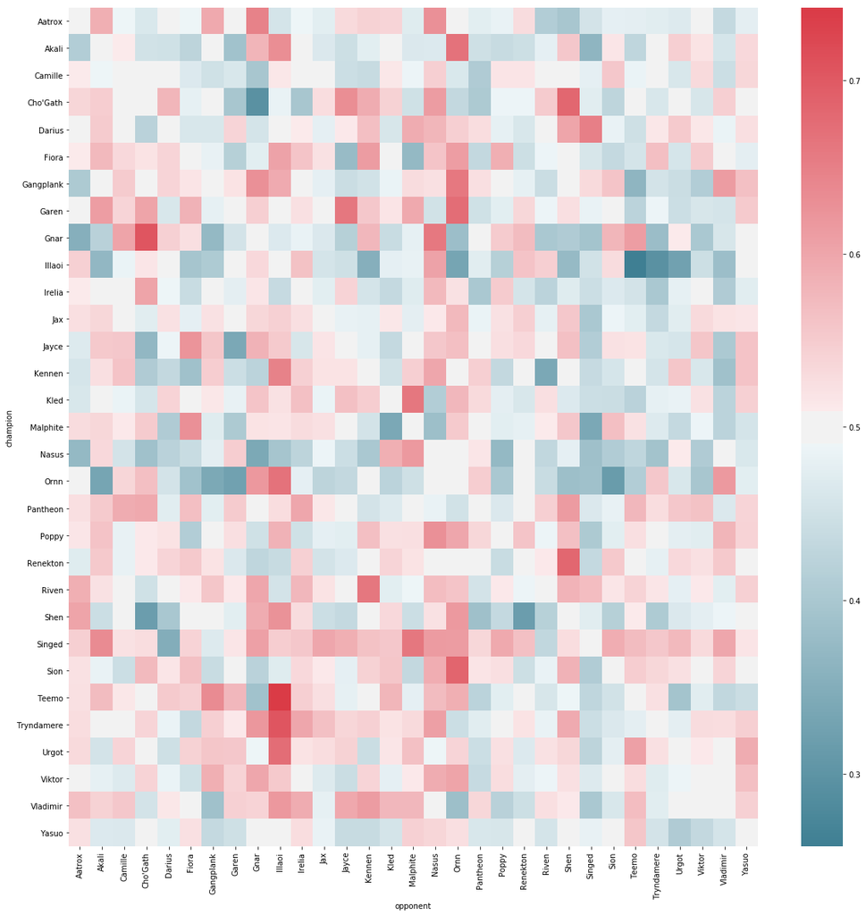

```python
plt.figure(figsize=(20, 20))
heatmap(top)
```

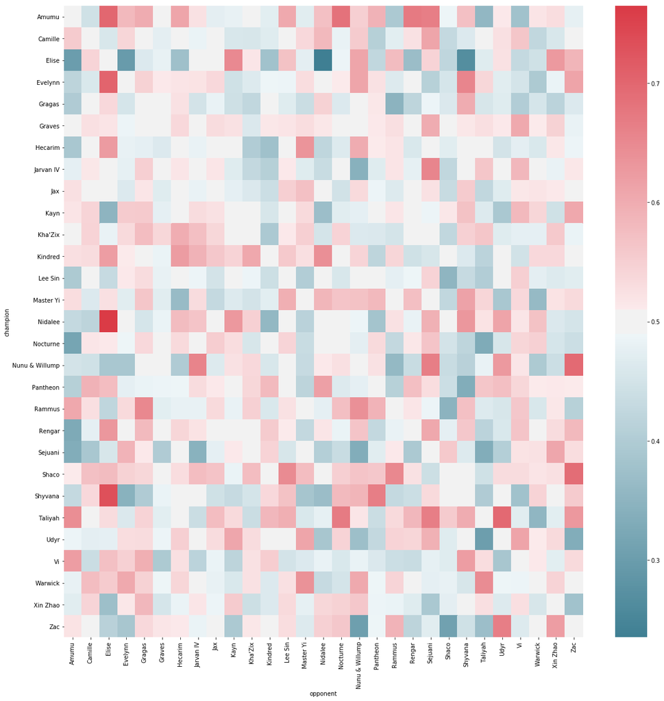

```python
plt.figure(figsize=(20, 20))
heatmap(jg)
```

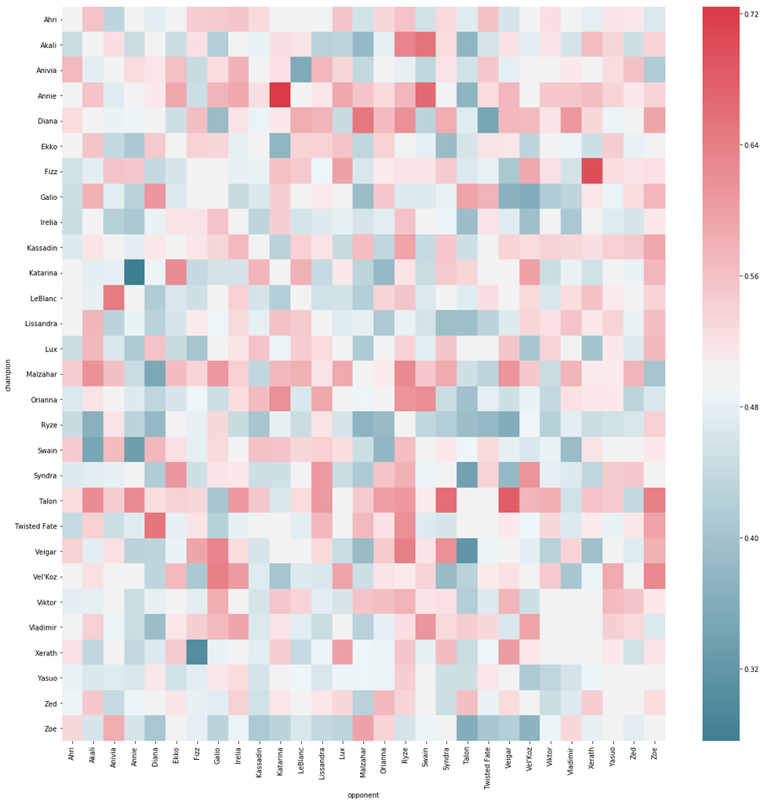

```python
plt.figure(figsize=(20, 20))
heatmap(mid)
```

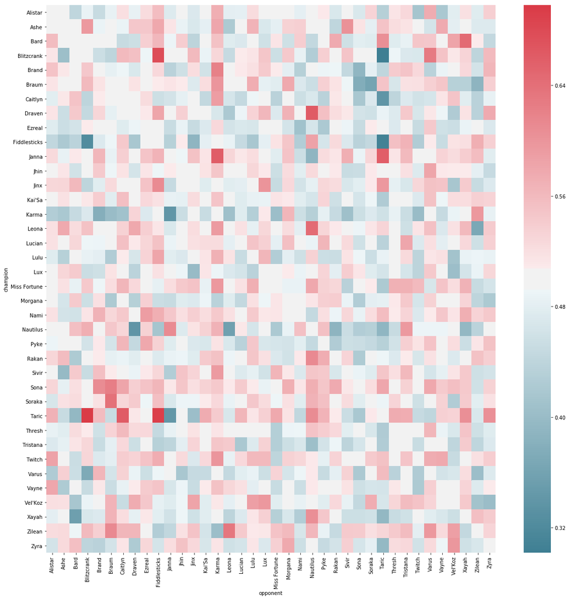

```python
plt.figure(figsize=(20, 20))
heatmap(bot)
```

## Early Game or Late Game Champions

In addition to this, there are champions that scaled better. When I was talking about ADC (Attack Damage Carry) these champions often do better as the game gets longer and longer. I will find which champions excel in the early game and which excel at the end game. I find data to see how long a game lasted and see if that specific champion won. This way I can see if the game lasted long enough to get to "late game". Each champion has different powerspikes (when they are stronger then most other champions if they were in the same position) and knowing when a champion is strong can help people know who aggressivly or passively they should play.

```python
#get winrate over time
overTime = {}
for champId in champData:
    overTime[champId] = champData[champId].drop(champData[champId].columns.difference(['win','csDiffPerMinDeltas', 'xpDiffPerMinDeltas']), 1)
    overTime[champId] = overTime[champId].dropna()
```

```python
WR = {}
for champId in overTime:
    temp = [[0,1],[0,0],[0,0],[0,0],[0,0]]
    for index, row in overTime[champId].iterrows():
        if row['win'] == True:
            temp[len(row['csDiffPerMinDeltas'])][0] = temp[len(row['csDiffPerMinDeltas'])][0] + 1
        temp[len(row['csDiffPerMinDeltas'])][1] = temp[len(row['csDiffPerMinDeltas'])][1]+1
    WR[champId] = temp

WRperPhase = {}

for champId in WR:
    WRperPhase[champId] = []
    for index in WR[champId]:
        if index[1] != 0:
            WRperPhase[champId].append(index[0]/index[1])
    del WRperPhase[champId][0]
```

These graphs below show how certain champions can either get better or worse as the game continues. Galio would be considered an early game champ due to his high resistances that cannot be broken while olaf power spikes once he has lvl 6 and can be a menace to the opponents. These graph exemplify how each champions have different powerspikes and know when to exploit them.

```python
def WRperTime(id):
    #print(WRperPhase(id))
    #fig.suptitle(champIdToName[id]['name'], fontsize=16)
    plt.title(champIdToName[id]['name'])
    plt.plot(['10-20', '20-30', '30-40', '40+'],WRperPhase[id])
    plt.plot(['10-20', '20-30', '30-40', '40+'], [.5,.5,.5,.5], color='k', linestyle='--')
    plt.ylim([min(WRperPhase[id])-.05,max(WRperPhase[id])+.05])
    plt.show()
```

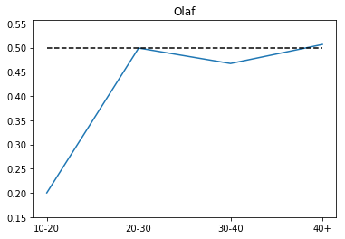

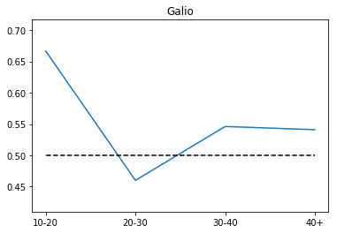

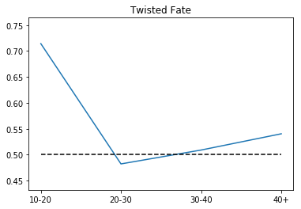

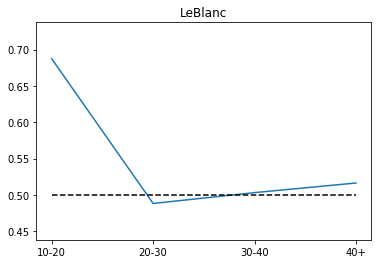

```python
WRperTime(2)
WRperTime(3)
WRperTime(4)
WRperTime(7)
```

## Objectives and their importance

I will try to predict who wins a game of league of legends using linear regression. The main features that I am using to determine who would win a game is, baron kills, first blood, inhibitors taken, towers, dragons killed, kills, vision score, xp and creep score.

Baron is an objective that does a lot of damage however, the team that managaes to slay it gets a massive buff an dgives the team 1.5k gold. This is the most contested objective in the game and can be stolen away at any time. SO each team must prep the baron to make sure there is no chance of it being stolen.

Then to get to the nexus, a team has to destory 3 towers in any specific lane. These towers are always protected since each time one goes down, it means that the team is that much closer to losing and an exposed nexus.

Inhibitors are placed inside the base and give the enemy team a buff. They spawn super minions that have more armor/health and do more damage. Having these super minions allows a team to get objectives on the map that much easier since they are alway pushing to the enemy base.

Lastly, there are dragons that give specific buffs based on which dragon is slayed. THe spawn of the dragon is random and no one knows which one is spawning but there is only 5 options, infernal, mountain, cloud, ocean, and elder. Elder only spawns after 36 mins and isnt alway part of every game however, before then it can be 1 of the 4 dragons I mentioned before. Infernal gives the team a stat boost on their offensive stats. Mountain allows the team to do more damage to stuctures and objectives. Cloud gives the team a movement speed boost when out of combat and lastly ocean gives the team a increased regen when out of combat.

All thesee objectives can influence the outcome of a game and are always highly contested, and with my analysis I will see which have the highest corellation to winning a game.

I originally added all the cs, xp, vision score and kills together however I felt like that does not give an accurate representation of the game since if a game goes longer a losing team can have a higher score for all categories just based on the fact that the game lasted long. So I ran two tests, 1 with pure data and 2 with the difference between the teams.

```python
predictDF = pd.DataFrame(columns=['teamId', 'win', 'baronKills', 'firstBlood', 'inhibitorKills', 'towerKills', 'dragonKills', 'kills', 'visionScore', 'xp', 'cs'])
diffDF = pd.DataFrame(columns=['teamId', 'win', 'baronKills', 'firstBlood', 'inhibitorKills', 'towerKills', 'dragonKills', 'kills', 'visionScore', 'xp', 'cs'])
p = 0
x = 0
y = 0
z = 0

for match in matchData:
    t1 = []
    t0 = []
    tempdf = pd.DataFrame(columns=['teamId', 'kills', 'visionScore', 'xp', 'cs'])
    #print("ID = "+str(match['gameId'])+" y = "+str(y))
    y = y + 1
    #get each participants data
    for part in match['participants']:
        temp = []
        teamId = 1
        if part['teamId'] == 200:
            temp.append(0)
        else:
            temp.append(1)
        temp.append(part['stats']['kills'])
        temp.append(part['stats']['visionScore'])
        if 'xpPerMinDeltas' in part['timeline']:
            xpdif = part['timeline']['xpPerMinDeltas']
            dif = 0
            for key, value in xpdif.items():
                dif = dif + (value*10)
            temp.append(dif)
            #xp[teamId] = xp[teamId] + dif
            dif = 0
            csdif = part['timeline']['creepsPerMinDeltas']
            for key, value in csdif.items():
                dif = dif + (value*10)
            temp.append(dif)
            #cs[teamId] = cs[teamId] + dif
            tempdf.loc[p] = temp
            p = p + 1
    #get the sum of all the participants for each team
    if 'xpPerMinDeltas' in match['participants'][0]['timeline']:
        for team in match['teams']:
            temp = []
            temp.append(team['teamId'])
            if team['win'] == "Fail":
                temp.append(0)
            else:
                temp.append(1)
            temp.append(team['baronKills'])
            if team['firstBlood'] == True:
                temp.append(1)
            else:
                temp.append(0)
            temp.append(team['inhibitorKills'])
            temp.append(team['towerKills'])
            temp.append(team['dragonKills'])
            #combine the 2 dataframes into an organized collection
            if (team['teamId'] == 100):
                temp = temp + tempdf[tempdf['teamId'] == 1].sum().drop('teamId').tolist()
                t1 = temp
            else:
                temp = temp + tempdf[tempdf['teamId'] == 0].sum().drop('teamId').tolist()
                t2 = temp
            predictDF.loc[x] = temp
            x = x + 1
        d = []
        for idx, val in enumerate(t1):
            d.append(val-t2[idx])
        diffDF.loc[z] = d
        z = z + 1
        d = []
        for idx, val in enumerate(t2):
            d.append(val-t1[idx])
        diffDF.loc[z] = d
        z = z + 1
```

## Linear Regression

My null hypothesis is that each of the features play an impact on who would win the game.

These are the dataframe I was able to construct with the data I had. The predictDF shows the average statistics for all matchs. diffDF is used to make sure that the data had no errors inside it. Since the mean of all the stats is 0, it means that the +/- is accurately done.

```python
predictDF.describe()
```

|  | teamId | win | baronKills | firstBlood | inhibitorKills | towerKills | dragonKills | kills | visionScore | xp | cs |
| --- | --- | --- | --- | --- | --- | --- | --- | --- | --- | --- | --- |
| count | 90636.000000 | 90636.000000 | 90636.000000 | 90636.000000 | 90636.000000 | 90636.000000 | 90636.000000 | 90636.000000 | 90636.000000 | 90636.000000 | 90636.000000 |
| mean | 150.000000 | 0.500000 | 0.437817 | 0.500000 | 0.939207 | 5.575720 | 1.412000 | 26.972505 | 127.524196 | 53209.938572 | 530.803351 |
| std | 50.000276 | 0.500003 | 0.605345 | 0.500003 | 1.172171 | 3.705802 | 1.184903 | 11.254288 | 54.628836 | 22725.425280 | 191.619230 |
| min | 100.000000 | 0.000000 | 0.000000 | 0.000000 | 0.000000 | 0.000000 | 0.000000 | 0.000000 | 0.000000 | 3670.000000 | 32.000000 |
| 25% | 100.000000 | 0.000000 | 0.000000 | 0.000000 | 0.000000 | 2.000000 | 0.000000 | 19.000000 | 92.000000 | 39205.000000 | 415.000000 |
| 50% | 150.000000 | 0.500000 | 0.000000 | 0.500000 | 1.000000 | 6.000000 | 1.000000 | 27.000000 | 125.000000 | 43584.500000 | 476.000000 |
| 75% | 200.000000 | 1.000000 | 1.000000 | 1.000000 | 2.000000 | 9.000000 | 2.000000 | 35.000000 | 161.000000 | 68458.000000 | 662.000000 |
| max | 200.000000 | 1.000000 | 4.000000 | 1.000000 | 11.000000 | 11.000000 | 7.000000 | 82.000000 | 437.000000 | 123811.000000 | 1235.000000 |

```python
diffDF.describe()
```

|  | teamId | win | baronKills | firstBlood | inhibitorKills | towerKills | dragonKills | kills | visionScore | xp | cs |
| --- | --- | --- | --- | --- | --- | --- | --- | --- | --- | --- | --- |
| count | 90636.000000 | 90636.000000 | 90636.000000 | 90636.000000 | 90636.000000 | 90636.000000 | 90636.000000 | 90636.000000 | 90636.000000 | 90636.0000 | 90636.000000 |
| mean | 0.000000 | 0.000000 | 0.000000 | 0.000000 | 0.000000 | 0.000000 | 0.000000 | 0.000000 | 0.000000 | 0.0000 | 0.000000 |
| std | 100.000552 | 1.000006 | 0.970213 | 1.000006 | 1.984649 | 6.724151 | 2.086072 | 13.481868 | 32.769642 | 6906.9977 | 68.212517 |
| min | -100.000000 | -1.000000 | -4.000000 | -1.000000 | -10.000000 | -11.000000 | -7.000000 | -47.000000 | -204.000000 | -39016.0000 | -436.000000 |
| 25% | -100.000000 | -1.000000 | -1.000000 | -1.000000 | -1.000000 | -6.000000 | -2.000000 | -12.000000 | -22.000000 | -4512.0000 | -43.000000 |
| 50% | 0.000000 | 0.000000 | 0.000000 | 0.000000 | 0.000000 | 0.000000 | 0.000000 | 0.000000 | 0.000000 | 0.0000 | 0.000000 |
| 75% | 100.000000 | 1.000000 | 1.000000 | 1.000000 | 1.000000 | 6.000000 | 2.000000 | 12.000000 | 22.000000 | 4512.0000 | 43.000000 |
| max | 100.000000 | 1.000000 | 4.000000 | 1.000000 | 10.000000 | 11.000000 | 7.000000 | 47.000000 | 204.000000 | 39016.0000 | 436.000000 |

Since we are only looking at these features I had to get only these columns to predict if that team wins or loses

```python
feature_names = ['baronKills', 'firstBlood', 'inhibitorKills', 'towerKills', 'dragonKills', 'kills', 'visionScore', 'xp', 'cs']
X = predictDF[feature_names]
y = predictDF['win']

X_train, X_test, y_train, y_test = train_test_split(X, y, random_state=0)

scaler = MinMaxScaler()
X_train = scaler.fit_transform(X_train)
X_test = scaler.transform(X_test)
```

```python
#feature_names = ['baronKills', 'firstBlood', 'inhibitorKills', 'towerKills', 'dragonKills', 'kills', 'visionScore', 'xp', 'cs']
diffX = diffDF[feature_names]
diffy = diffDF['win']

diffX_train, diffX_test, diffy_train, diffy_test = train_test_split(diffX, diffy, random_state=0)

diffscaler = MinMaxScaler()
diffX_train = diffscaler.fit_transform(diffX_train)
diffX_test = scaler.transform(diffX_test)
```

The logistic regression had a higher rate of success when it was handed raw data. This means that most games actually are very similar and have a general trend. This can occur due to the fact that there is a thing called a "meta". Most games are played to this meta. In this season, the meta was focused around aggresive plays and punishing the enemy's teams mistakes. This leads to shorter games and champions that are better for the earely game so that they can "snowball" the rest of the game.

```python
logreg = LogisticRegression()
logreg.fit(X_train, y_train)
print('Accuracy of Logistic regression classifier on training set: {:.2f}'
     .format(logreg.score(X_train, y_train)))
print('Accuracy of Logistic regression classifier on test set: {:.2f}'
     .format(logreg.score(X_test, y_test)))
```

```
Accuracy of Logistic regression classifier on training set: 0.93
Accuracy of Logistic regression classifier on test set: 0.93
```

```python
difflogreg = LogisticRegression()
difflogreg.fit(diffX_train, diffy_train)
print('Accuracy of Logistic regression classifier on training set: {:.2f}'
     .format(logreg.score(diffX_train, diffy_train)))
print('Accuracy of Logistic regression classifier on test set: {:.2f}'
     .format(logreg.score(diffX_test, diffy_test)))
```

```
Accuracy of Logistic regression classifier on training set: 0.50
Accuracy of Logistic regression classifier on test set: 0.45
```

```python
X1 = predictDF[feature_names]
y = predictDF['win']
lm = linear_model.LinearRegression()
model = lm.fit(X,y)
```

```python
diffX1 = diffDF[feature_names]
diffy = diffDF['win']
difflm = linear_model.LinearRegression()
diffmodel = difflm.fit(diffX,diffy)
```

```python
lm.score(X,y)
```

```
0.7313913143444895
```

```python
difflm.score(diffX,diffy)
```

```
0.847681051114507
```

This shows the coefficient of each feature on determining on who would win the game. The higher a coefficient the more of an impact that specfic feature has on the end results. From these we can rank the most important things in the game. However, the cs, xp, vision score, kills would have almost a 0 coefficient since this is just random amounts of kills and xp due to outliers and certain games lasting longer. However, when looking at the diffDF we found that xp still has almost 0 coefficient but cs, kills and vision had a much more of an impact.

IN ORDER OF IMPORTANCE for raw data

1. Towers
2. Baron
3. Dragons
4. First blood
5. Kills
6. XP
7. CS
8. Vision
9. Inhibitors

IN ORDER OF IMPORTANCE for diff data

1. Baron
2. Tower
3. Inhib
4. Kills
5. Dragons
6. CS
7. XP
8. Vision
9. First Blood

```python
sk_coeffs = lm.coef_.tolist()
for attr, coef in zip(feature_names, sk_coeffs):
    print("Attribute: {}, Coefficient: {}".format(attr,coef))
```

```
Attribute: baronKills, Coefficient: 0.09624840738379167
Attribute: firstBlood, Coefficient: 0.017846065173473494
Attribute: inhibitorKills, Coefficient: -0.012120914286271208
Attribute: towerKills, Coefficient: 0.10655053819551706
Attribute: dragonKills, Coefficient: 0.026173859363061325
Attribute: kills, Coefficient: 0.004930861583824188
Attribute: visionScore, Coefficient: -0.0009302941947225079
Attribute: xp, Coefficient: -5.227824609169844e-06
Attribute: cs, Coefficient: -6.403564307416176e-05
```

```python
sk_coeffs = difflm.coef_.tolist()
for attr, coef in zip(feature_names, sk_coeffs):
    print("Attribute: {}, Coefficient: {}".format(attr,coef))
```

```
Attribute: baronKills, Coefficient: 0.10094971894098631
Attribute: firstBlood, Coefficient: -0.015340802877267879
Attribute: inhibitorKills, Coefficient: 0.03185611610928515
Attribute: towerKills, Coefficient: 0.07955584831509062
Attribute: dragonKills, Coefficient: 0.003781016365525605
Attribute: kills, Coefficient: 0.02175938553665751
Attribute: visionScore, Coefficient: -0.0013306775877674776
Attribute: xp, Coefficient: 6.380698222280664e-06
Attribute: cs, Coefficient: 0.00014944727061256681
```

```python
sm_y = y
sm_X = X

#add a constant to the features
sm_X = sm.add_constant(X)

# use Ordinary Least Squares
OLS_model = sm.OLS(y,X).fit()
OLS_model.summary()
```

OLS Regression Results

| Dep. Variable: | win | R-squared: | 0.863 |
| --- | --- | --- | --- |
| Model: | OLS | Adj. R-squared: | 0.863 |
| Method: | Least Squares | F-statistic: | 6.370e+04 |
| Date: | Sat, 15 Dec 2018 | Prob (F-statistic): | 0.00 |
| Time: | 12:36:40 | Log-Likelihood: | -6949.3 |
| No. Observations: | 90636 | AIC: | 1.392e+04 |
| Df Residuals: | 90627 | BIC: | 1.400e+04 |
| Df Model: | 9 |  |  |
| Covariance Type: | nonrobust |  |  |

|  | coef | std err | t | P>\|t\| | [0.025 | 0.975] |
| --- | --- | --- | --- | --- | --- | --- |
| baronKills | 0.0872 | 0.002 | 46.069 | 0.000 | 0.083 | 0.091 |
| firstBlood | 0.0284 | 0.002 | 16.084 | 0.000 | 0.025 | 0.032 |
| inhibitorKills | -0.0157 | 0.001 | -11.599 | 0.000 | -0.018 | -0.013 |
| towerKills | 0.1066 | 0.001 | 202.034 | 0.000 | 0.106 | 0.108 |
| dragonKills | 0.0236 | 0.001 | 24.186 | 0.000 | 0.022 | 0.026 |
| kills | 0.0074 | 0.000 | 56.200 | 0.000 | 0.007 | 0.008 |
| visionScore | -0.0009 | 2.41e-05 | -36.294 | 0.000 | -0.001 | -0.001 |
| xp | -7.913e-06 | 1.46e-07 | -54.187 | 0.000 | -8.2e-06 | -7.63e-06 |
| cs | 0.0003 | 1.48e-05 | 20.066 | 0.000 | 0.000 | 0.000 |

| Omnibus: | 1718.173 | Durbin-Watson: | 2.326 |
| --- | --- | --- | --- |
| Prob(Omnibus): | 0.000 | Jarque-Bera (JB): | 3481.292 |
| Skew: | -0.080 | Prob(JB): | 0.00 |
| Kurtosis: | 3.947 | Cond. No. | 1.28e+05 |

Warnings:  
[1] Standard Errors assume that the covariance matrix of the errors is correctly specified.  
[2] The condition number is large, 1.28e+05. This might indicate that there are  
strong multicollinearity or other numerical problems.

```python
diffsm_y = diffy
diffsm_X = diffX

#add a constant to the features
diffsm_X = sm.add_constant(diffX)

# use Ordinary Least Squares
diffOLS_model = sm.OLS(diffy,diffX).fit()
diffOLS_model.summary()
```

OLS Regression Results

| Dep. Variable: | win | R-squared: | 0.848 |
| --- | --- | --- | --- |
| Model: | OLS | Adj. R-squared: | 0.848 |
| Method: | Least Squares | F-statistic: | 5.604e+04 |
| Date: | Sat, 15 Dec 2018 | Prob (F-statistic): | 0.00 |
| Time: | 12:36:43 | Log-Likelihood: | -43328. |
| No. Observations: | 90636 | AIC: | 8.667e+04 |
| Df Residuals: | 90627 | BIC: | 8.676e+04 |
| Df Model: | 9 |  |  |
| Covariance Type: | nonrobust |  |  |

|  | coef | std err | t | P>\|t\| | [0.025 | 0.975] |
| --- | --- | --- | --- | --- | --- | --- |
| baronKills | 0.1009 | 0.002 | 57.521 | 0.000 | 0.098 | 0.104 |
| firstBlood | -0.0153 | 0.001 | -11.366 | 0.000 | -0.018 | -0.013 |
| inhibitorKills | 0.0319 | 0.002 | 21.103 | 0.000 | 0.029 | 0.035 |
| towerKills | 0.0796 | 0.001 | 129.115 | 0.000 | 0.078 | 0.081 |
| dragonKills | 0.0038 | 0.001 | 4.657 | 0.000 | 0.002 | 0.005 |
| kills | 0.0218 | 0.000 | 105.691 | 0.000 | 0.021 | 0.022 |
| visionScore | -0.0013 | 4.87e-05 | -27.327 | 0.000 | -0.001 | -0.001 |
| xp | 6.381e-06 | 2.95e-07 | 21.613 | 0.000 | 5.8e-06 | 6.96e-06 |
| cs | 0.0001 | 2.34e-05 | 6.397 | 0.000 | 0.000 | 0.000 |

| Omnibus: | 790.915 | Durbin-Watson: | 2.994 |
| --- | --- | --- | --- |
| Prob(Omnibus): | 0.000 | Jarque-Bera (JB): | 1294.490 |
| Skew: | 0.000 | Prob(JB): | 8.04e-282 |
| Kurtosis: | 3.585 | Cond. No. | 9.54e+03 |

Warnings:  
[1] Standard Errors assume that the covariance matrix of the errors is correctly specified.  
[2] The condition number is large, 9.54e+03. This might indicate that there are  
strong multicollinearity or other numerical problems.

We can see that the P value of each of these features is almost 0. This shows that each feature has a impact on the prediction of who would win the game. The difference between the objectives is very small but once the games goes to a proffessional level, these small details can make or break a team. Knowing this knowledge, a team can figure out if it is worth dying or trading objectives based on their priority on the game.